# Project 2026

**English**

# Pheromone-Based Mosquito Control in Residential Areas Using Dispersers located in Public-Space

### Spatial distribution of ovitraps

**Description**

This report presents the weekly monitoring of oviposition patterns of Aedes aegypti —2026 season— in the Tigre district, located in the northern area of the Buenos Aires Metropolitan Area.

The sampling area consists of six plots distributed across the cities of Don Torcuato, El Talar, General Pacheco, and Benavídez. These are organized into three treatment plots (A, B, and C) and three control plots (D, E, and F).

Each plot, composed of blocks of 7 × 7 city blocks (approximately 0.5 km²), includes 18 ovitraps installed at fixed sampling points (see map for their location). The ovitraps are checked and replaced weekly.

#### Ovitrap mapping

The map presents the temporal dynamics and spatial distribution of *Aedes aegypti* egg counts using ovitraps. The color of the points reflects oviposition intensity, while the size indicates the magnitude of the records, facilitating the identification of areas with the highest vector activity.

**Navigation instructions**

- Each circle represents the spatial location of an ovitrap.
- Both the color and the size of the circles indicate the number of eggs recorded: higher values are represented by more intense colors (from yellow to red) and larger circle diameters.
- By clicking on an ovitrap, information about the week, the section or label, the ovitrap number, and the number of eggs recorded is displayed.
- The right-hand side panel allows selecting and viewing different sampling weeks.

[interactive chart not shown]

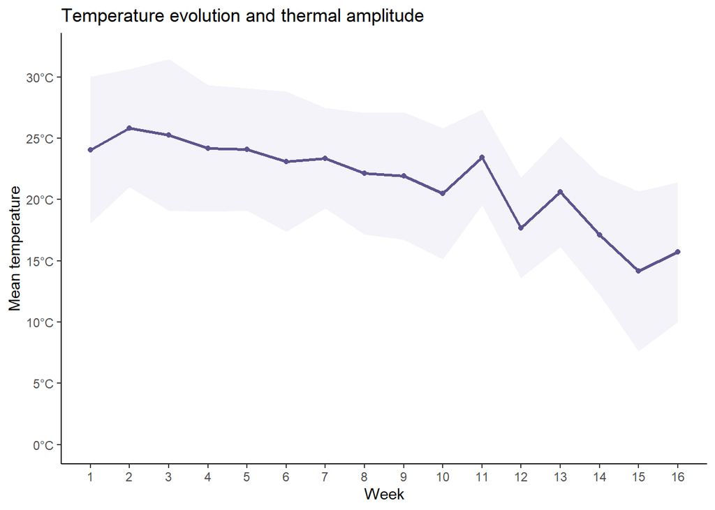

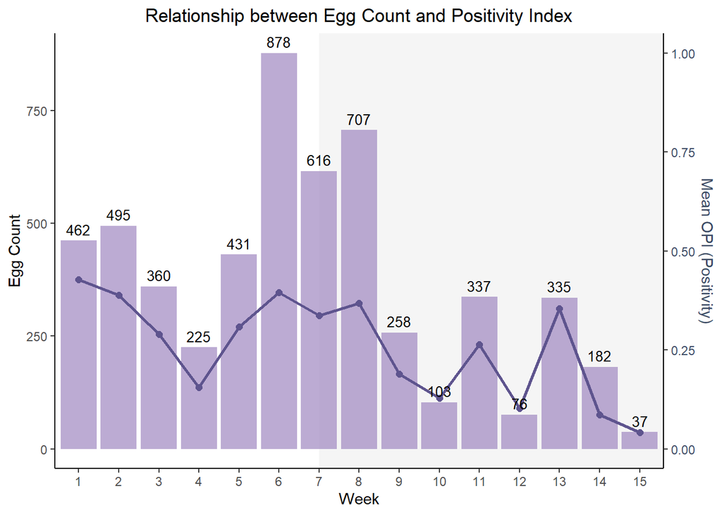

> The following section presents second-order indicators designed to evaluate the interaction between the vector population and the areas under treatment.

**Charts**

The interactive chart shown below details the temporal dynamics of the oviposition index recorded by ovitraps at the various sampling points.

*How to interact with the chart*

- **Filter sections:** click on a legend item to show or hide a section.
- **Focus on one section:** double-click a legend item to isolate it.
- **Restore all:** double-click again to display all sections.
- **Detailed information:** hover over a point to see additional data.
- **Zoom:** click and drag over the chart to zoom into a specific range.
- **Pan:** drag the chart to move across the data.
- **Reset view:** use the “reset zoom” button in the top-right corner.

[interactive chart not shown]

*Fig. 1. Temporal evolution of the oviposition index for all evaluated plots. The oviposition index is calculated as the total number of ovitraps with eggs divided by the total number of ovitraps collected. Purple points represent treatment plots and green points represent control plots. Point size is proportional to the number of ovitraps with eggs collected per plot and sampling week.*

Persistency Curve

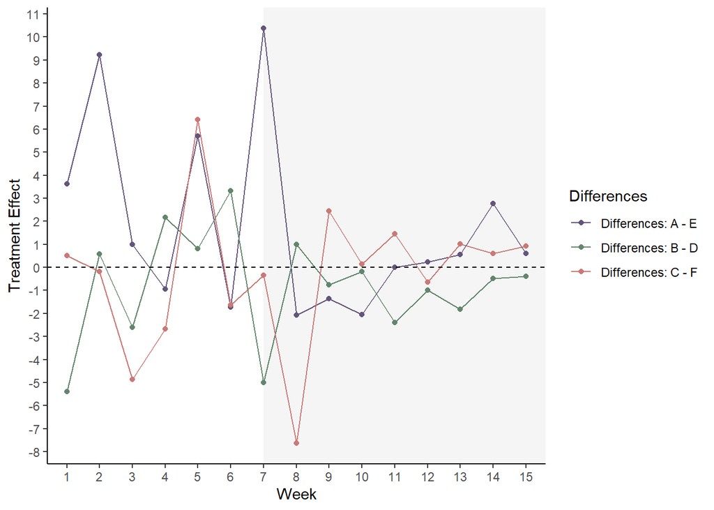

**Español**

# Control de mosquitos en áreas residenciales mediante el uso de feromonas liberadas por dispersores ubicados en espacios públicos

### Distribución espacial de ovitrampas

**Descripción**

Este informe presenta el monitoreo semanal de los patrones de oviposición de Aedes aegypti —temporada 2026— en el partido de Tigre, ubicado en la zona norte del Área Metropolitana de Buenos Aires.

El área de muestreo está compuesta por seis parcelas distribuidas en las cuidades de Don Torcuato, El Talar, General Pacheco y Benavídez. Estas se organizan en tres parcelas de tratamiento (A, B y C) y tres parcelas de control (D, E y F).

Cada parcela, compuesta por bloques de 7 x 7 cuadras (aproximado de 0,5 km²), cuenta con 18 ovitrampas instaladas en puntos fijos de muestreo (ver mapa para su localización). Las ovitrampas se revisan y reemplazan semanalmente.

#### Mapeo de ovitrampas

El mapa presenta la dinámica temporal y espacial del conteo de huevos de *Aedes aegypti* mediante ovitrampas. En esta visualización, el color de los puntos refleja la intensidad de la oviposición y su tamaño indica la magnitud del registro, facilitando la identificación de las áreas con mayor actividad del vector.

**Instrucciones de navegación**

- Cada círculo representa la localización espacial de una ovitrampa.
- Tanto el color como el tamaño de los círculos indican la cantidad de huevos registrados: valores más altos se representan con colores de mayor intensidad (de amarillo a rojo) y círculos de mayor diámetro.
- Al hacer clic sobre una ovitrampa, se visualiza la información de la semana, la sección o etiqueta, el número de la ovitrampa y la cantidad de huevos registrados.
- El panel lateral derecho permite seleccionar y visualizar las distintas semanas de muestreo.

[interactive chart not shown]

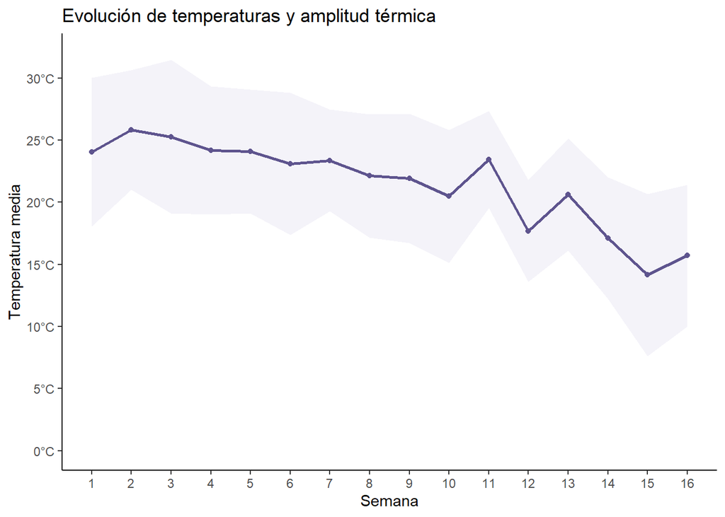

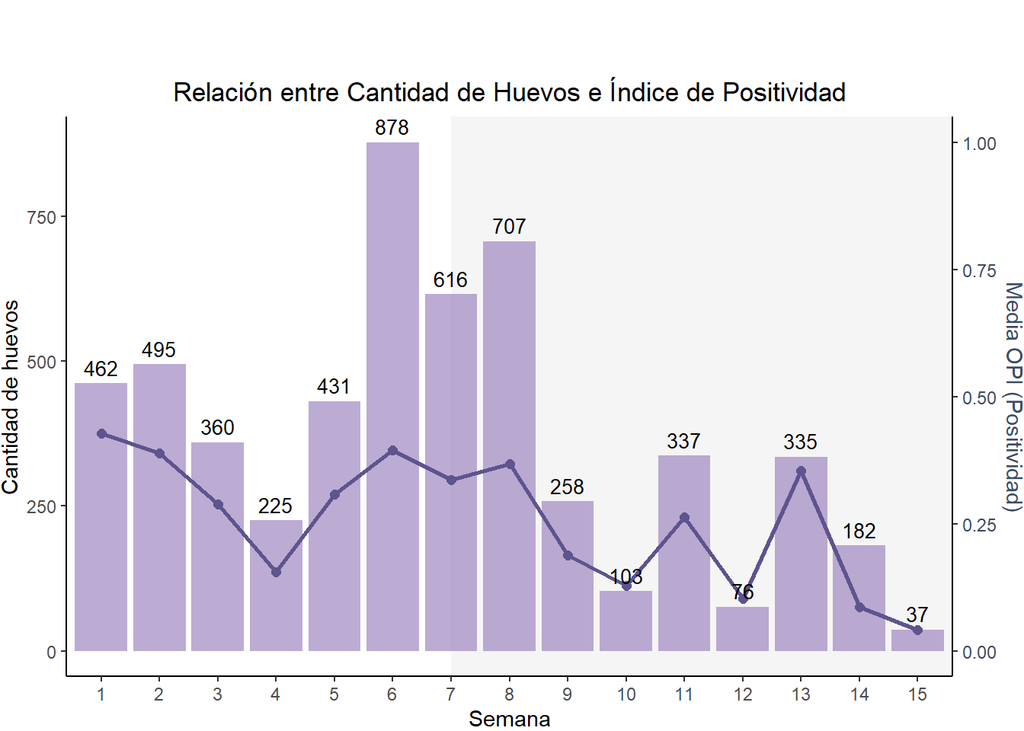

> A continuación, se presentan indicadores de segundo orden diseñados para evaluar la interacción entre la población de vectores y las áreas bajo tratamiento.

**Gráficos**

El gráfico interactivo que se muestra a continuación detalla la evolución temporal del índice de oviposición registrado en las ovitrampas de los distintos puntos de muestreo.

*Cómo interactuar con el gráfico*

- **Filtrar secciones:** hacé clic en una etiqueta de la leyenda para mostrar u ocultar una sección.
- **Ver una sola sección:** doble clic sobre una etiqueta para aislarla.
- **Restaurar todas:** doble clic nuevamente para volver a mostrar todas las secciones.
- **Información detallada:** al pasar el cursor sobre un punto, se despliega información específica.
- **Zoom:** hacé clic y arrastrá sobre el gráfico para hacer zoom en un rango de interés.
- **Moverse (pan):** arrastrá el gráfico para desplazarte.
- **Restablecer vista:** usá el botón de “reset zoom” en la esquina superior derecha.

[interactive chart not shown]

*Fig 1. Evolución temporal del índice de oviposición para todas las parcelas evaluadas. El índice de oviposición se calcula como el total de ovitrampas con huevos dividido por el total ovitrampas recolectadas. Los puntos violetas representan los tratamientos y los verdes los controles. El tamaño del punto es proporcional la cantidad de ovitrampas con huevos recolectadas por parcela y semana de muestreo.*

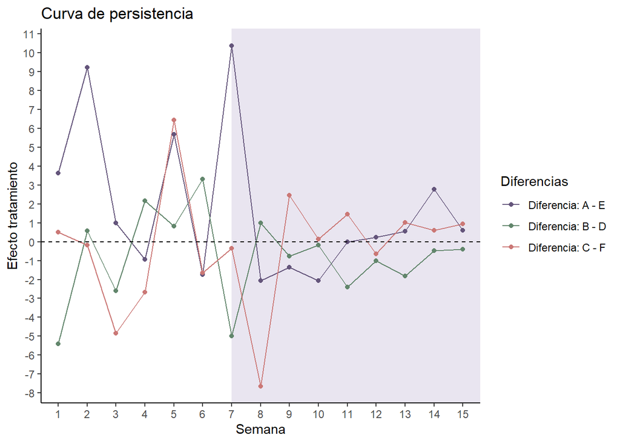